# Assignment modue no 7 In R

CAR Data Cleaning and practicing

Description of dataset:- sourcing information is silent , dont know whrere is data came form, we hopind a imaginary car dataset,as It is a Car dataset we are more intrested into looking into MPG:- milage per gallon of dataset for gaining more and more inforamation out of it.

```r
# Read CSV, note the delimiter (sep) shoud be given if it is required
df <- read.csv('Cars.csv')
```

```r
head(df) # type of attributes and feature of my corresponnding data
```

A data.frame: 6 × 5

|  | HP <int> | MPG <dbl> | VOL <int> | SP <dbl> | WT <dbl> |
| --- | --- | --- | --- | --- | --- |
| 1 | 49 | 53.70068 | 89 | 104.1854 | 28.76206 |
| 2 | 55 | 50.01340 | 92 | 105.4613 | 30.46683 |
| 3 | 55 | 50.01340 | 92 | 105.4613 | 30.19360 |
| 4 | 70 | 45.69632 | 92 | 113.4613 | 30.63211 |
| 5 | 53 | 50.50423 | 92 | 104.4613 | 29.88915 |
| 6 | 70 | 45.69632 | 89 | 113.1854 | 29.59177 |

What is menaing of meaning of data that shoud be understood first HP - Engine Horse power , MPG- Milage per galloon(Average miles per gallon) , VOL -Cubic feet of cab space , SP- Speed per hour , Wt - Weight of the vehicle

But those data does not represent the vehicle items or car names From which the data came from , I am just taking each observation of index no 1 to 81 as like Numbers of Cars in this dataset.

```r
summary(df) # this is the summary of our data .
```

```
       HP             MPG             VOL               SP
 Min.   : 49.0   Min.   :12.10   Min.   : 50.00   Min.   : 99.56
 1st Qu.: 84.0   1st Qu.:27.86   1st Qu.: 89.00   1st Qu.:113.83
 Median :100.0   Median :35.15   Median :101.00   Median :118.21
 Mean   :117.5   Mean   :34.42   Mean   : 98.77   Mean   :121.54
 3rd Qu.:140.0   3rd Qu.:39.53   3rd Qu.:113.00   3rd Qu.:126.40
 Max.   :322.0   Max.   :53.70   Max.   :160.00   Max.   :169.60
       WT
 Min.   :15.71
 1st Qu.:29.59
 Median :32.73
 Mean   :32.41
 3rd Qu.:37.39
 Max.   :53.00
```

### Playing with Attributes of data

```r
str(df) # we have the data types are of numeric and integer
```

```
'data.frame':	81 obs. of  5 variables:
 $ HP : int  49 55 55 70 53 70 55 62 62 80 ...
 $ MPG: num  53.7 50 50 45.7 50.5 ...
 $ VOL: int  89 92 92 92 92 89 92 50 50 94 ...
 $ SP : num  104 105 105 113 104 ...
 $ WT : num  28.8 30.5 30.2 30.6 29.9 ...
```

# Data preprocessing : clenaing >

```r
library(dplyr) # include lobrary dplyr
```

```r
glimpse(df) # we also can check and process
```

```
Rows: 81
Columns: 5
$ HP  <int> 49, 55, 55, 70, 53, 70, 55, 62, 62, 80, 73, 92, 92, 73, 66, 73,...
$ MPG <dbl> 53.70068, 50.01340, 50.01340, 45.69632, 50.50423, 45.69632, 50....
$ VOL <int> 89, 92, 92, 92, 92, 89, 92, 50, 50, 94, 89, 50, 99, 89, 89, 89,...
$ SP  <dbl> 104.1854, 105.4613, 105.4613, 113.4613, 104.4613, 113.1854, 105...
$ WT  <dbl> 28.76206, 30.46683, 30.19360, 30.63211, 29.88915, 29.59177, 30....
```

```r
anyNA(df) # this means there is no navalue present no missing value to impute
```

FALSE

```r
var(df) # values varies from the mean
```

A matrix: 5 × 5 of type dbl

|  | HP | MPG | VOL | SP | WT |
| --- | --- | --- | --- | --- | --- |
| HP | 3261.95216 | -378.12837 | 98.66142 | 788.76944 | 32.74306 |
| MPG | -378.12837 | 83.38328 | -107.73967 | -88.98055 | -36.04097 |
| VOL | 98.66142 | -107.73967 | 497.35679 | 32.31302 | 166.96778 |
| SP | 788.76944 | -88.98055 | 32.31302 | 201.11300 | 10.88507 |
| WT | 32.74306 | -36.04097 | 166.96778 | 10.88507 | 56.14225 |

some how i will findout intrepareation of different data in order to understand its feature i need to see its different corleantio point of each data types and correlaiion of each coulumns lets get numeric value of each column

```r
num_col  <- sapply(df,is.numeric)
```

```r
num_col # got the numeric value as true
```

**HP**

TRUE

**MPG**

TRUE

**VOL**

TRUE

**SP**

TRUE

**WT**

TRUE

```r
cor.data  <- cor(df[,num_col]) # finding the correaltion between afte taking columns to row for comparision
```

```r
print(cor.data)
```

```
             HP        MPG         VOL         SP          WT
HP   1.00000000 -0.7250383  0.07745947  0.9738481  0.07651307
MPG -0.72503835  1.0000000 -0.52905658 -0.6871246 -0.52675909
VOL  0.07745947 -0.5290566  1.00000000  0.1021700  0.99920308
SP   0.97384807 -0.6871246  0.10217001  1.0000000  0.10243919
WT   0.07651307 -0.5267591  0.99920308  0.1024392  1.00000000
```

```r
cor(df) # we can also find cortrelation of data as well
```

A matrix: 5 × 5 of type dbl

|  | HP | MPG | VOL | SP | WT |
| --- | --- | --- | --- | --- | --- |
| HP | 1.00000000 | -0.7250383 | 0.07745947 | 0.9738481 | 0.07651307 |
| MPG | -0.72503835 | 1.0000000 | -0.52905658 | -0.6871246 | -0.52675909 |
| VOL | 0.07745947 | -0.5290566 | 1.00000000 | 0.1021700 | 0.99920308 |
| SP | 0.97384807 | -0.6871246 | 0.10217001 | 1.0000000 | 0.10243919 |
| WT | 0.07651307 | -0.5267591 | 0.99920308 | 0.1024392 | 1.00000000 |

```r
library(corrplot)
library(corrgram)
```

# Exploratory data annalysis:-

```
             HP        MPG         VOL         SP          WT
HP   1.00000000 -0.7250383  0.07745947  0.9738481  0.07651307
MPG -0.72503835  1.0000000 -0.52905658 -0.6871246 -0.52675909
VOL  0.07745947 -0.5290566  1.00000000  0.1021700  0.99920308
SP   0.97384807 -0.6871246  0.10217001  1.0000000  0.10243919
WT   0.07651307 -0.5267591  0.99920308  0.1024392  1.00000000
```

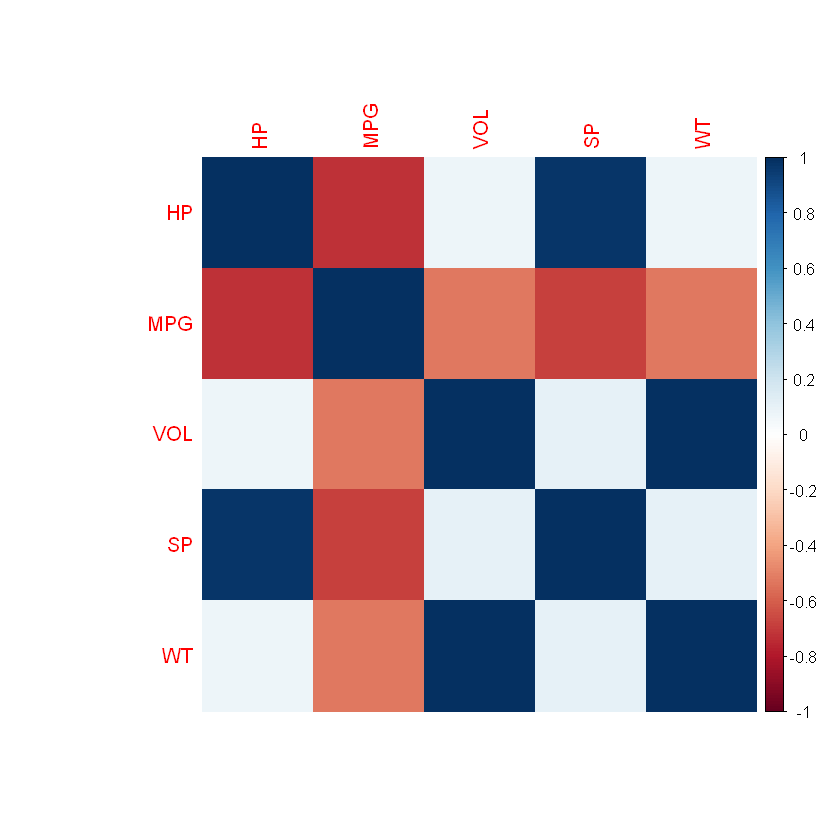

```r
print(corrplot(cor.data,method = 'color'))
```

looke here we find out there is high correaltion between hp as we can see it through digonally. it shows also there is some correlation exist between volume andn weight

To visualise more meaningfull insite from the informaiton lets do corrgram

```
             HP        MPG         VOL         SP          WT
HP   1.00000000 -0.7250383  0.07745947  0.9738481  0.07651307
MPG -0.72503835  1.0000000 -0.52905658 -0.6871246 -0.52675909
VOL  0.07745947 -0.5290566  1.00000000  0.1021700  0.99920308
SP   0.97384807 -0.6871246  0.10217001  1.0000000  0.10243919
WT   0.07651307 -0.5267591  0.99920308  0.1024392  1.00000000
```

[figure not shown]

```r
print(corrgram(cor.data))
```

[figure not shown]

```r
corrgram(df,order=TRUE,lower.panel = panel.shade,upper.panel = panel.ellipse,text.panel = panel.txt)
```

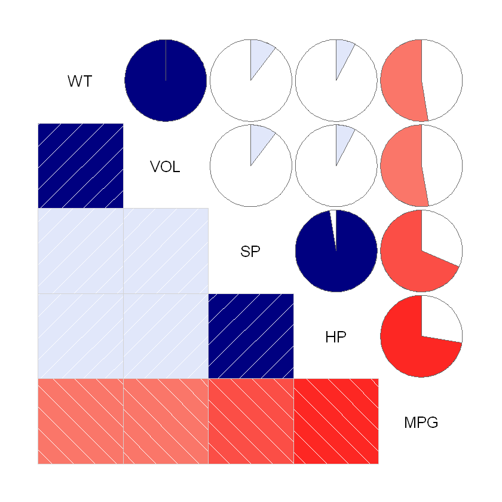

```r
corrgram(df,order=TRUE,lower.panel = panel.shade,upper.panel = panel.pie,text.panel = panel.txt)
```

from the above weitht and volume perfectly correlated, and sp and sp also showes perfect correaltion aswell, as blue indicate posiitive correaltion and Hp and MPG negatively correalted as Red indicate negatice correaltinon

```r
attach(df)
```

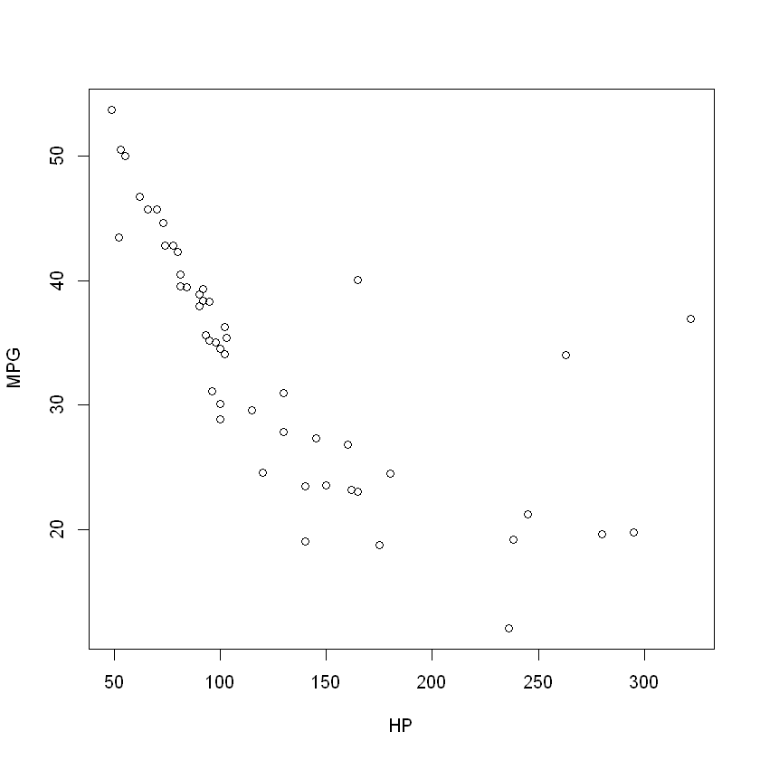

```r
plot(HP,MPG) # to see more visually at basice level also
```

from the above we can see there is some correalation exist in the variable HP and MPG

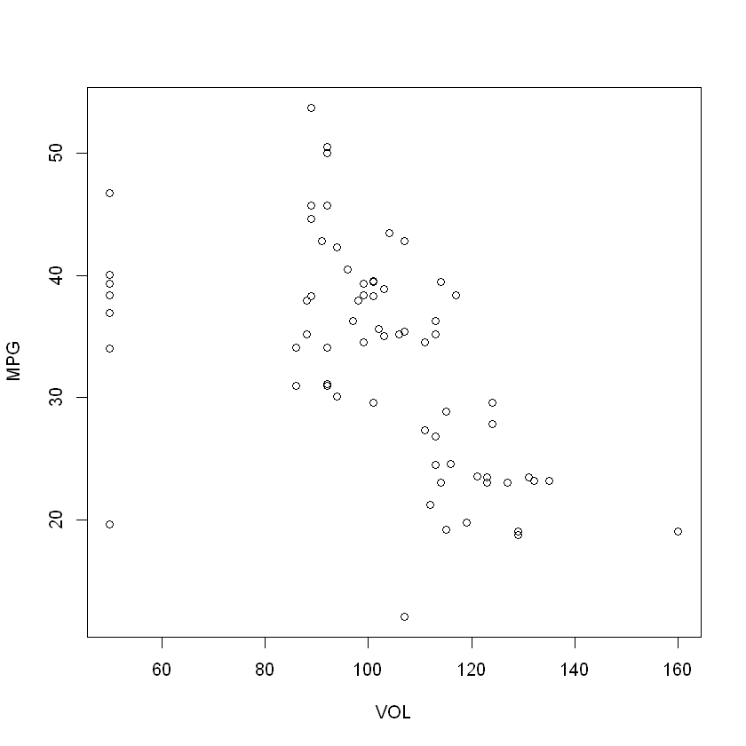

```r
plot(VOL,MPG)
```

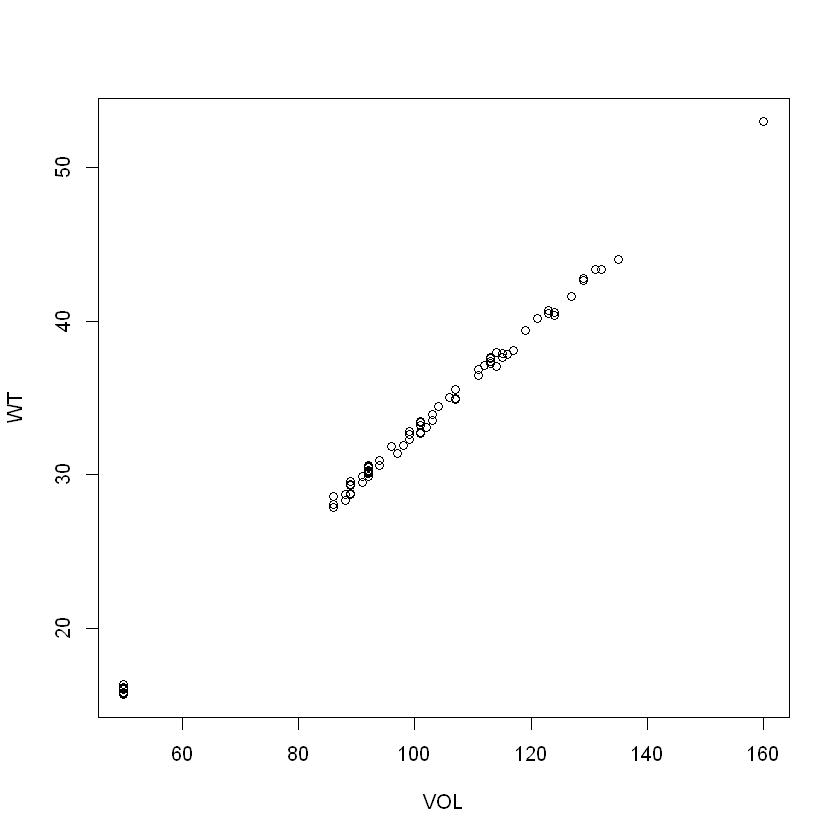

```r
plot(VOL,WT)
```

we can see there is a perfect correaltion exist between Vol and WT

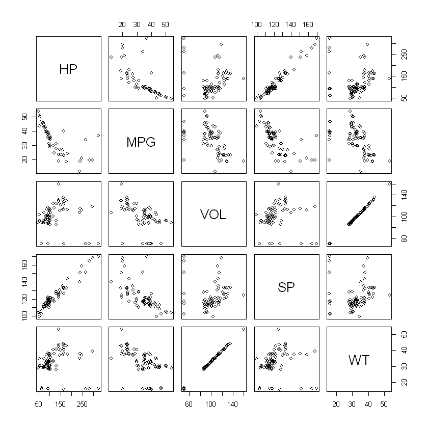

```r
pairs(df) # a basic visualization of correaltion of each variable
```

more visually we can see the correaltion of each variable both side shows positive and negative corealtion of each side

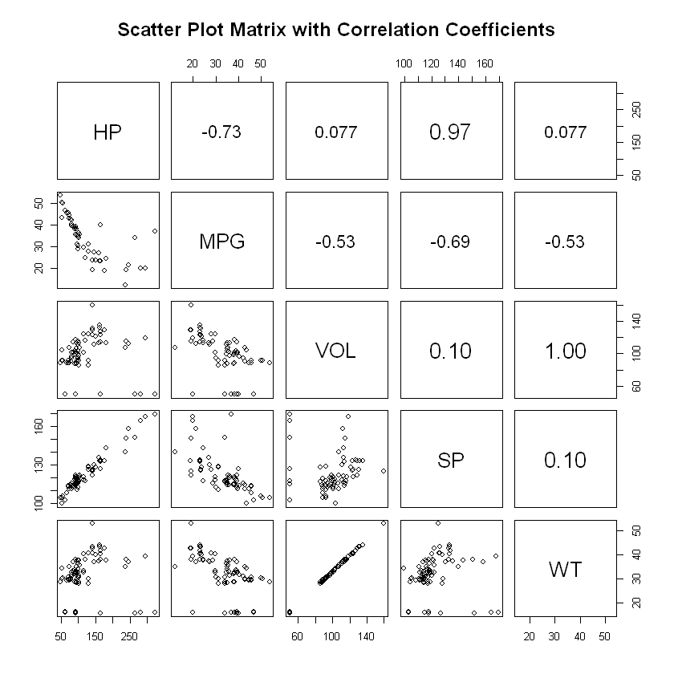

```r
panel.cor <- function(x, y, digits=2, prefix="", cex.cor)
{
  usr <- par("usr"); on.exit(par(usr))
  par(usr = c(0, 1, 0, 1))
  r = (cor(x, y))
  txt <- format(c(r, 0.123456789), digits=digits)[1]
  txt <- paste(prefix, txt, sep="")
  if(missing(cex.cor)) cex <- 0.4/strwidth(txt)
  text(0.5, 0.5, txt, cex = cex)
}
pairs(df, upper.panel=panel.cor,main="Scatter Plot Matrix with Correlation Coefficients")
#we
```

we can see more insight about negative and positive correalion with numeric explanaiton and with representation.

Lets Checkout each variable are normal or not

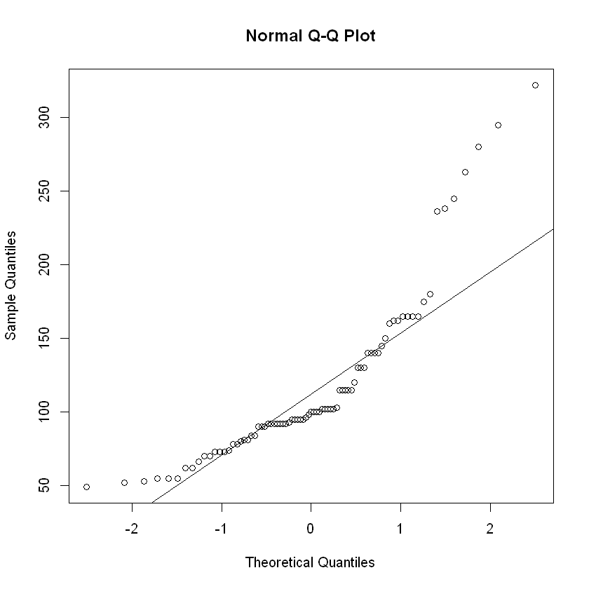

```r
qqnorm(HP)
qqline(HP)
```

Though all the values are not on the line , it means it is not normal

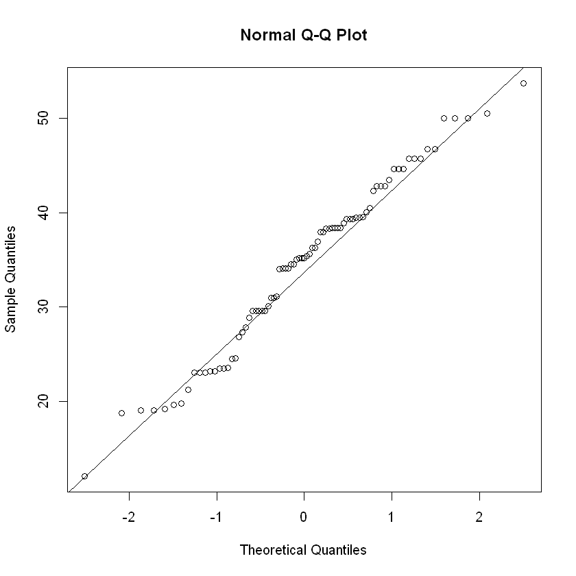

```r
qqnorm(MPG)
qqline(MPG)
```

MPG is a normally distributed as its each points are little bit on the line

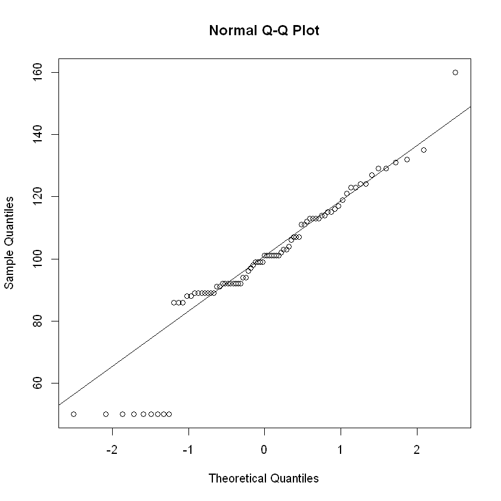

```r
qqnorm(VOL)
qqline(VOL)
```

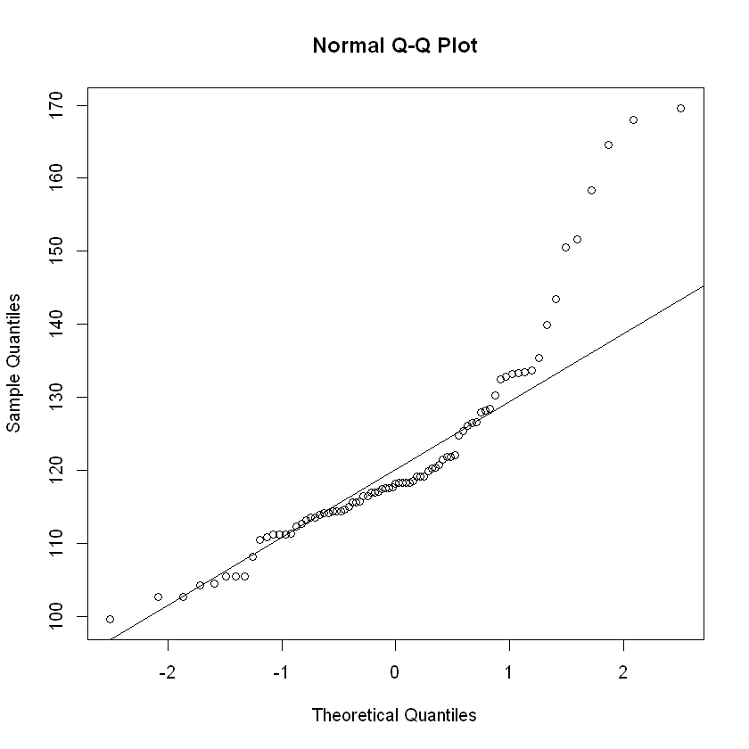

```r
qqnorm(SP)
qqline(SP)
```

SP is not normally Distributed

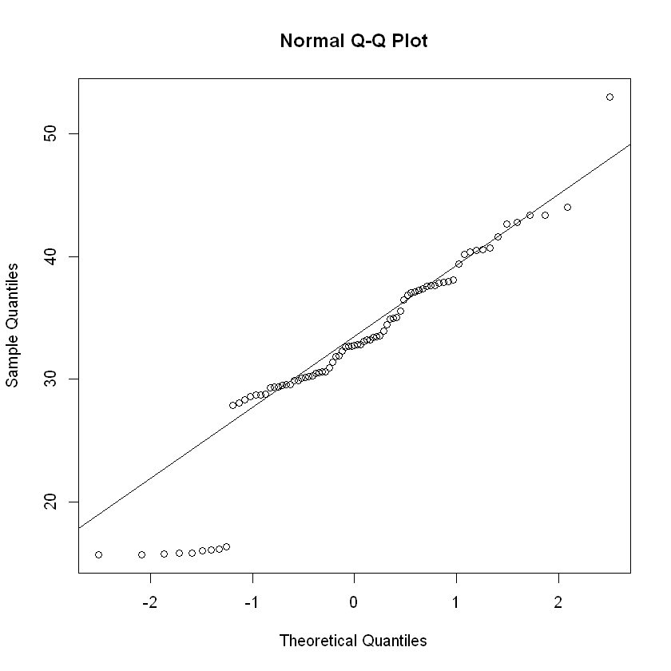

```r
qqnorm(WT)
qqline(WT)
```

### Splitting our data into train and test

```r
library(ISLR)
```

```r
sample_siz = floor(0.70*nrow(df))
```

```r
sample_siz # of 70 percent of 81 ovservation
```

56

# Train test split for Random value will be selected each time

```r
set.seed(101) # this will give random value each time
train_random = sample(seq_len(nrow(df)),size = sample_siz) # i have generated random data set
train = df[train_random,] # i have now train and test data
test = df[-train_random,] # after deduction from test random i got test data also
```

```r
model = lm(MPG ~ WT+SP+VOL+HP,data = train) # created a linear model car
model # we built our model ,now lets check summary of it and what we will gain form it
```

```
Call:
lm(formula = MPG ~ WT + SP + VOL + HP, data = train)

Coefficients:
(Intercept)           WT           SP          VOL           HP
    12.5615      -0.2142       0.5964      -0.1440      -0.2507
```

```r
summary(model)
```

```
Call:
lm(formula = MPG ~ WT + SP + VOL + HP, data = train)

Residuals:
     Min       1Q   Median       3Q      Max
-10.2540  -2.5345  -0.8392   1.3699  14.5829

Coefficients:
            Estimate Std. Error t value Pr(>|t|)
(Intercept) 12.56147   18.72330   0.671  0.50531
WT          -0.21420    2.05635  -0.104  0.91745
SP           0.59641    0.20051   2.975  0.00447 **
VOL         -0.14403    0.68910  -0.209  0.83527
HP          -0.25074    0.04929  -5.087 5.28e-06 ***
---
Signif. codes:  0 '***' 0.001 '**' 0.01 '*' 0.05 '.' 0.1 ' ' 1

Residual standard error: 4.418 on 51 degrees of freedom
Multiple R-squared:  0.8025,	Adjusted R-squared:  0.787
F-statistic: 51.81 on 4 and 51 DF,  p-value: < 2.2e-16
```

lets predict our model what we made

```r
MPG.predict  <- predict.lm(model,test)
```

```r
result  <- cbind(MPG.predict,test$MPG) # im storing pridicted value with actual in resutl
colnames(result)  <- c('Predicted','Acutal')# created predicted and actual column
results  <- as.data.frame(result) # stored values in results a new vector
print(head(results)) # and printing out actual and precicted
```

```
   Predicted   Acutal
4   42.86710 45.69632
5   41.92108 50.50423
7   41.92620 50.01340
11  41.46138 44.65283
12  49.05476 39.35409
15  41.43075 45.73489
```

we did and predicted our model too but is it correct as we think , lets check for any outlier , and any variable which actually influence or giving bad results , before going into it you must have some domain knowledge , here doimain knowledge comes into play without domain knowledge your all effort is useless

## But here we will first identify outlier and remove it

```r
library(car) # to visualize our model in plotting method we use car plot
```

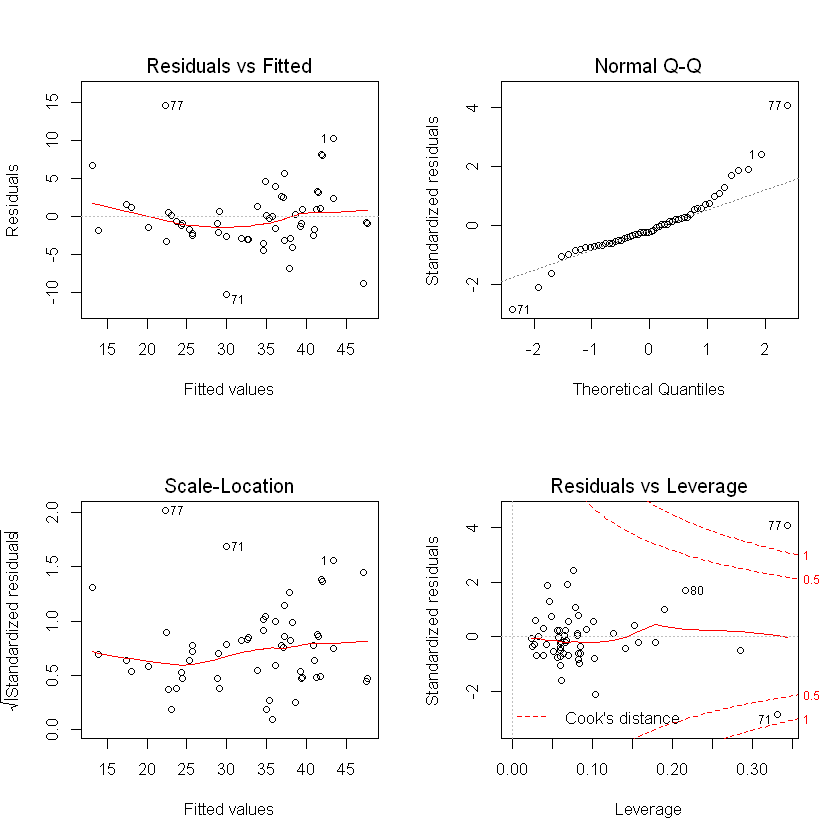

```r
par(mfrow = c(2,2)) # we created square row and column to visualse the summary
plot(model)# 77 item is a outlier
```

from above by plotting our model we find that in out model there is ourlier, standardised residials ,and leverage in our data value of 770

**71**

18

**77**

25

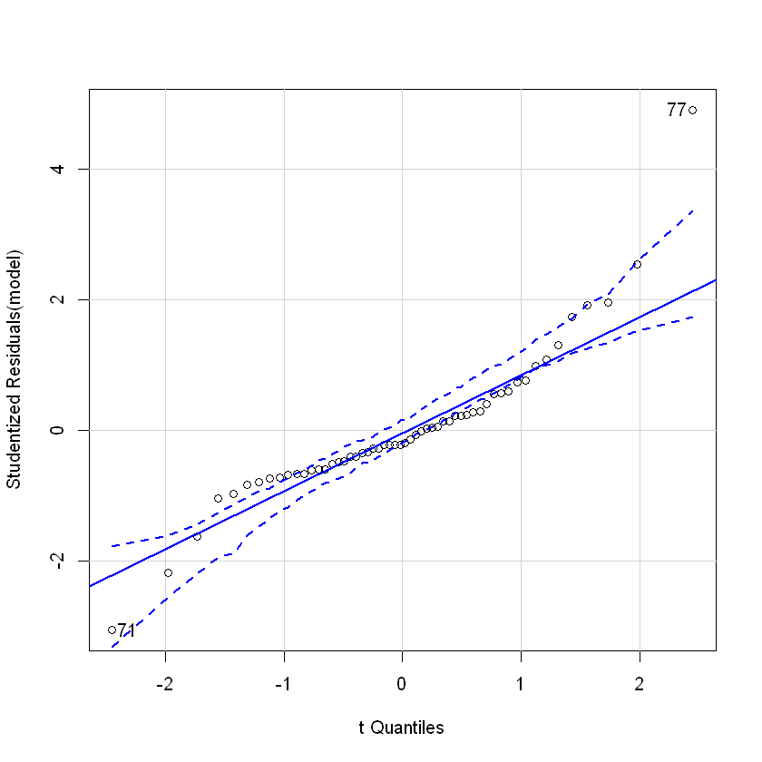

```r
qqPlot(model,identify.n=6) # QQ plots of studentized residuals, helps identify outliers
# as we can see the value 77 is the outlier in our model
# if you see both positive and negative side 77 th item on positive is highly influencing
```

What is the meaning of the above variable it is the superflows car that is generally impacting overall cars data as irrilivant means the general perfomance of all cars are some how little vary but this is drastically changing value of all other variables , so it is a ourlier we have to remove it , as it is not part of our investigatiosn. so we removing the 77 value car number

```r
influence.measures(model) # ltes try some other method to find the influence factor too
```

```
Influence measures of
	 lm(formula = MPG ~ WT + SP + VOL + HP, data = train) :

      dfb.1_   dfb.WT    dfb.SP  dfb.VOL    dfb.HP    dffit cov.r   cook.d
73 -2.86e-03 -0.00323  0.001766  0.00345 -1.18e-03  0.00936 1.180 1.79e-05
57 -2.21e-01 -0.03231  0.211764  0.03273 -1.97e-01 -0.25028 1.122 1.26e-02
46 -3.58e-03 -0.02350 -0.001063  0.02356  4.61e-03 -0.05544 1.119 6.25e-04
58 -4.96e-02  0.13256  0.057475 -0.13290 -5.37e-02 -0.18147 1.116 6.65e-03
61  4.75e-02 -0.10716 -0.052950  0.10614  4.58e-02 -0.15862 1.136 5.09e-03
60 -3.39e-02  0.04952  0.041302 -0.05194 -3.20e-02 -0.13395 1.097 3.63e-03
59 -1.93e-01  0.06807  0.190025 -0.06764 -1.76e-01 -0.26281 1.056 1.38e-02
3   8.80e-02  0.06289 -0.047834 -0.06507 -1.29e-02  0.41001 0.811 3.20e-02
32  3.05e-02  0.02772 -0.023799 -0.02735  1.23e-02  0.10320 1.097 2.16e-03
9  -5.79e-02 -0.03511  0.045724  0.03709 -4.01e-02 -0.09053 1.339 1.67e-03
31 -5.99e-02 -0.24338  0.040779  0.24678 -6.23e-02  0.31874 1.067 2.02e-02
```

[output cut: 102 more lines]